# Лабораторная работа No 2.

Тагиев Б. А.

Российский университет дружбы народов, Москва, Россия

15 сентября 2023

## Цель работы

Получение практических навыков работы в консоли с атрибутами файлов, закрепление теоретических основ дискреционного разграничения доступа в современных системах с открытым кодом на базе ОС Linux

## Выполнение лабораторной работы

1. Создать пользователя guest. При помощи команды

```
yes 1 | adduser guest
```

2. Задать новому пользователю пароль, при помощи утилиты passwd.
3. Войти в новую сессию под пользователем guest.

## Выполнение лабораторной работы

4. Открыть терминал и посмотреть в какой мы директории. Для этого будет использовать pwd (print workdir). Вывод команды можно увидеть на картинке. Данная директория является домашней для пользователя guest.

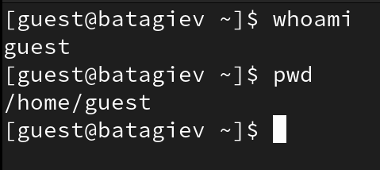

Домашняя директория и вывод whoami

## Выполнение лабораторной работы

5. Для того, чтобы узнать username пользоваться, воспользуемся командой whoami.

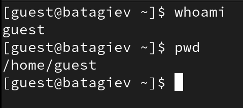

Домашняя директория и вывод whoami

## Выполнение лабораторной работы

6. Посмотрим на вывод команды id. Там мы видим UID, GID и дополнительные метки пользователя. Вывод информации о группах сопоставим с тем, что мы увидем, при запуске команды groups.

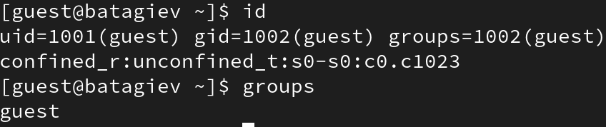

id и groups

## Выполнение лабораторной работы

7. Пользователь guest и в приглашение командной строки имеет в себе username guest.
8. В файле `/etc/passwd` лежит информация о всех пользователях системы. UID = 1001, GUID=1002.

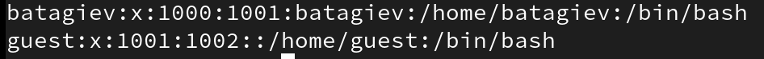

/etc/passwd

## Выполнение лабораторной работы

9. В директории `/home/` у нас находятся все папки для каждого пользователя системы (кроме системных пользователей). На обоих папках права выставлены 700.

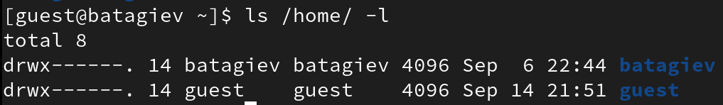

/home директория

## Выполнение лабораторной работы

10. Расширенные атрибуты удастся посмотреть только для директорий, до которых может достучаться пользователь. Потому там и появилась ошибка доступа.

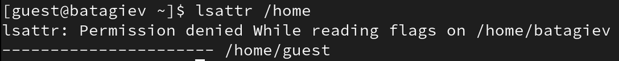

lsattr /home директории

## Выполнение лабораторной работы

11. Создадим директорию `dir1` в домашнем каталоге. Посмотрим на ее права и атрибуты. На dir1 выставлены права 755.

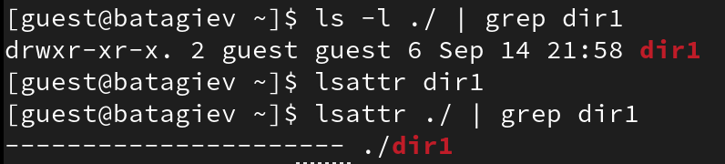

dir1

## Выполнение лабораторной работы

12. Обнулим права доступа, при помощи chmod.

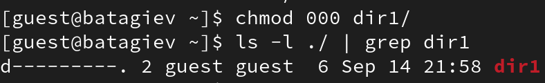

000 на dir1

## Выполнение лабораторной работы

13. При попытке создать файл — получаем ошибку доступа из-за отсутствия прав для кого-либо.

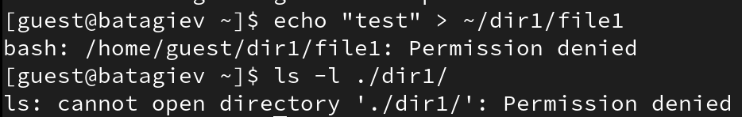

Создание файла в dir1

## Выполнение лабораторной работы

14. Заполним таблицу “Установленные права и разрешённые действия”.

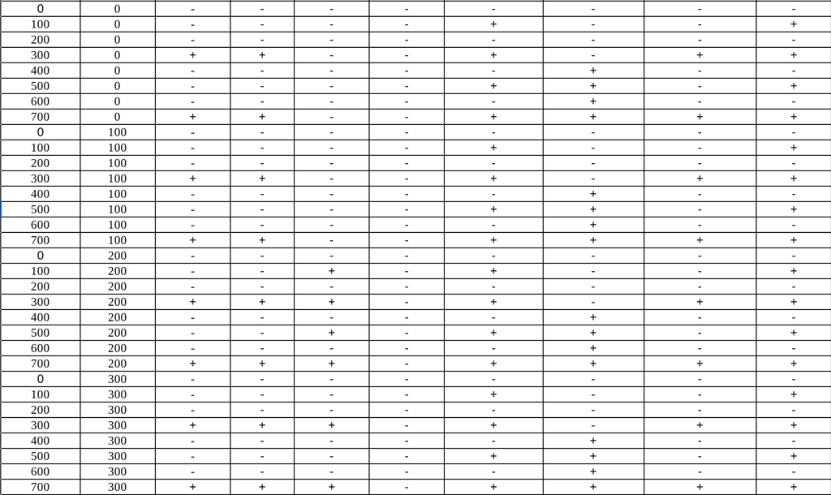

“Установленные права и разрешённые действия” ч. 1

## Выполнение лабораторной работы

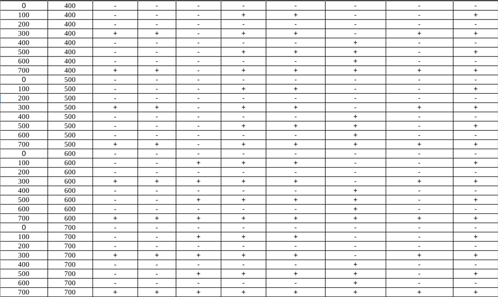

“Установленные права и разрешённые действия” ч. 2

## Выполнение лабораторной работы

15. На основе таблицы составим таблицу с “Минимальные права для совершения операций”.

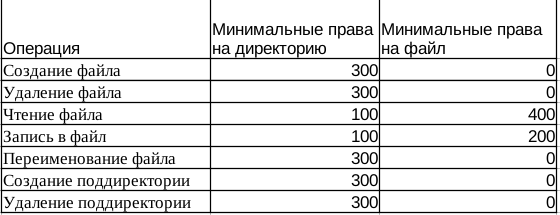

“Минимальные права для совершения операций”

## Выводы

По итогам выполнения работы, я приобрел навыки работы в консоли с атрибутами файлов.